# Estimating and testing for multiple structural changes with `mbreaks` package

Linh Nguyen, Pierre Perron, Yohei Yamamoto

This vignette is intended for users who use `mbreaks` to estimate and test for linear regression models in the presence of multiple structural changes. The package offers a set of comprehensive tools which deal with both pure and partial structural change models. In particular, it provides the Sup F tests for 0 versus a known number of structural changes and the double maximum (UD max) tests for 0 versus an unknown number of structural changes. The sequential tests for $l$ versus $l+1$ structural changes are also available to determine the number of structural changes (Bai and Perron (1998), Bai and Perron (2003)). The package also includes methods of estimating the number of structural changes via information criteria (Yao (1988), Liu et al. (1997)) as well as a built-in function to visualize the fit of the estimated structural break model with the estimated number $m^*$ of structural changes. A comprehensive call to conduct all of the procedures contained in package is provided.

## Econometric framework of `mbreaks` package

The package `mbreaks` provides R users with minimum but comprehensive functions to analyze multiple structural changes in linear regression models in which the regressors and errors are non-trending. The framework is based on the econometric model of the following form:

$$y_t = x_t^{\prime}\beta + z_t^{\prime} \delta_j + u_t; \\
t=T_{j-1}+1,...,T_j, {\quad}{\text{for}}{\quad}j=1,...,m+1$$
where $\underset{(p \times 1)}{x_t}$ is a vector of regressors with fixed coefficients (if any) and $\underset{(q \times 1)}{z_t}$ is a vector of regressors with coefficients subject to change. The break dates are $t=T_j$ for $j=1,...,m$ and $T_0=0$ and $T_{m+1}=T$ so that $T$ is the entire sample size. If $p=0$, the model is called a pure structural change model, and if $p>0$, the model is called a partial structural change model. The twofold goals of this package is to enable user to:

- Test for the presence of structural changes by:
  - supF tests for no structural change versus a known number of structural changes: `dotest()` (Bai and Perron (1998))
  - UDmax test for no structural change versus unknown number of structural changes: `dotest()` (Bai and Perron (1998))
- Select the number of structural changes ($m^*$) by:
  - sequential tests:
    - Determine the number of structural changes by using $\sup F_T(l+1|l)$ test: `dosequa()` (Bai and Perron (1998),Bai and Perron (2003))
    - Estimate one break at a time by using the repartition method: `dorepart()` (Bai (1997))
  - information criterion:
    - Bayesian Information Criterion (BIC): `doorder()` (Yao (1988))
    - Modified Schwarz Criterion (MSIC): `doorder()` (Liu et al. (1997))

If the number of structural changes is known (or specified), users can use `dofix()` function to estimate the model with the corresponding number of changes. There are 3 classes in the package, corresponding to 2 types of diagnostic tests and one for estimation based on the selected number of structural changes. In summary:

- `sbtests`: S3 class returned from `dotest()` function. It includes summary of the supF tests and UDmax test with test statistics, critical values, and summary tables which could be viewed in the console by `print()` method or open in a separated tab by `View()`
- `seqtests`: S3 class returned from `doseqtests()` function. It includes summary of the sequential tests for $l$ versus $l+1$ structural changes with test statistics, critical values and a summary table which could be viewed in the console via `print()` method or open in separated tab by `View()`
- `model`: S3 class returned from estimation procedures above including `dosequa()`, `doorder()`, `dorepart()`, and `dofix()` of models with $m^*$ structural changes. The class `model` contains numerous information which is summarized comprehensively into 3 main tables: i) break dates (estimated break dates and corresponding asymptotic confidence intervals based on assumptions on the regressors and errors), ii) regime-specific coefficients (estimates in each regime and corrected standard errors based on assumptions on the regressors and errors) and iii) full-sample coefficients if $p>0$ (estimates and corrected standard errors based on assumptions on the regressors and errors). Besides the information presented in the 3 main tables, `model` contains fields (with majority of them are class `matrix`) which users can access by using operator `$` for further analysis in R such as fitted values, residuals and the name of procedure used.

## Usage, arguments and examples

### Usage of main functions in `mbreaks`

The previous section introduced the framework on which `mbreaks` package is built and summarizes the classes of procedures available to users. In this section, we will illustrate the syntax of high-level functions and cover the arguments that users might want to customize to match their model with data and empirical strategy.

The `mbreaks` package designs high-level functions to have identical arguments with default values recommended by the literature to save users the burden. Users can use `mdl()`, a comprehensive function that invokes all high-level functions explained in previous section:[^1]

```r
#the data set for the example is real.Rda
data(real)
#carry out all testing and estimating procedures via a single call
rate = mdl('y',data=real)
#display the results from the procedures
rate
Number of max breaks specified:  5
-----------------------------------------------------
The number of breaks is estimated by BIC
Pure change model with 2 estimated breaks.
Minimum SSR = 455.950

Estimated date:
        Break1  Break2
Date        47      79
95% CI (37,50) (77,82)
90% CI (40,49) (78,81)

Estimated regime-specific coefficients:
                Regime 1       Regime 2      Regime 3
Const (SE) 1.355 (0.155) -1.796 (0.511) 5.643 (0.603)

No full sample regressors
-----------------------------------------------------
a) SupF tests against a fixed number of breaks

        1 break 2 breaks 3 breaks 4 breaks 5 breaks
Sup F    57.906   43.014   33.323   24.771   18.326
10% CV    7.040    6.280    5.210    4.410    3.470
5% CV     8.580    7.220    5.960    4.990    3.910
2.5% CV  10.180    8.140    6.720    5.510    4.340
1% CV    12.290    9.360    7.600    6.190    4.910

b) UDmax tests against an unknown number of breaks

   UDMax 10% CV  5% CV 2.5% CV  1% CV
1 57.906  7.460  8.880  10.390 12.370
-----------------------------------------------------
supF(l+1|l) tests using global optimizers under the null

               supF(2|1) supF(3|2) supF(4|3) supF(5|4)
Seq supF          33.927    14.725     0.033     0.000
Estimated date        47        24        64        NA
10% CV             7.040     8.510     9.410    10.040
5% CV              8.580    10.130    11.140    11.830
2.5% CV           10.180    11.860    12.660    13.400
1% CV             12.290    13.890    14.800    15.280
-----------------------------------------------------
To access additional information about specific procedures
  (not included above), type stored variable name + '$' + procedure name
```

Users should find the syntax minimal similar to `lm()` in `stats` package. It is required to specify the name of dependent variable $y$ followed by the two types of the regressors $z$ and $x$ from the data frame. Note that $z$ automatically includes a constant term. If the model is a pure structural change model, no $x$ is specified. If none of $z$ and $x$ are specified, the program assumes that this is a mean shift model (because a constant term is included in $z$ by default). The names of regressors must match the names used in the data frame, otherwise errors will be displayed and execution halted. As we will explain in the following section, the package prepares various options to be specified by users. These are set at default value if not specified in `mdl()` or any high-level functions of the procedures: `dotest()`, `dosequa()`, `doorder()`, `dorepart()`, and `dofix()`etc.

### Options for high-level functions

- The model requires a trimming value $\epsilon$ as a small interval of length $h = \lfloor \epsilon T\rfloor$ is required between any two adjacent segments. Users can modify $\epsilon$ in arguments passing to all high-level functions[^2] by setting $\epsilon{\quad} {\in}$ {0.05, 0.10, 0.15, 0.25}..[^3] If the user’s input value for `eps1` is invalid, it will be set to default value `eps1=0.15`.
- Argument `m` specifies the maximum number of breaks considered in the model. This argument is automatically matched with `eps1` argument. If the program finds that `m` is invalid (non-positive or larger than that allowed by the sample size given the trimming value `eps1`), it will be set automatically to maximal breaks allowed by the sample size and the specified trimming level `eps1`. The default value is `m=5`.
- The following options related to assumptions on the structure of long-run covariance matrix of ${z_tu_t}$ and ${x_tu_t}$ (if any):
  - `robust`: Allow for heteroskedasticity and autocorrelation in $u_t$. The default value is `robust=1`. If set to `robust=0`, the errors are assumed to be a martingale difference sequence.
  - `hetvar`: Allow the variance of the errors $u_t$ to be different across segments. This option is not allowed to be `0` when `robust=1`.
  - `prewhit`: Set to `1` if users want to prewhiten the residuals with an AR(1) process prior to estimating the long-run covariance matrix. The default value is `prewhit=1`.
- The following options related to the second moments of the regressors $z_t$ and $x_t$ (if any):
  - `hetdat`: Set to `1` to allow the second moment matrices of $z_t$ and $x_t$ (if any) to be different across segments. Set to `0` otherwise. It is recommended to set `hetdat=1` for $p>0$. The default value is `hetdat=1`
  - `hetq`: Set to `1` to allow the second moment matrices of $z_t$ and $x_t$ (if any) to be different across segments. This is used in construction of the confidence intervals for the break dates. If `hetq=0`, the second moment matrices of the regressors are assumed to be identical across segments. The default value is `hetq=1`.
  - `hetomega`: Set to `1` to allow the long-run covariance matrix of $z_t u_t$ to be different across segments. Set to `0` otherwise. This is used in construction of the confidence interval for the break dates. The default value is `hetomega=1`.
- Additional options specific to a partial structural change model:[^4]
  - `maxi`: Maximum number of iterations if no convergence attained when running the iterative procedure to estimate partial structural change model. The default is `maxi=20`
  - `eps`: Criterion for convergence of the iterative procedure. The default value is `eps=0.0001`
  - `fixb`: Set to 1 if users intend to provide initial values for $\beta$, where the initial values are supplied as matrix `betaini` of size $(p \times 1)$. If `betaini` is invalid, the program will automatically set `fixb=0` and use OLS estimate for the initial values. The default value is `fixb=0`

There are two options available to all high-level functions:

- `const`: Set to `1` to include constant in $z$. The default value is `const=1`. Users can turn off the constant in $z$ by setting `const=0`.
- `printd`: Set to `1` to print intermediate outputs from estimation procedures of the program to console. The default value is `printd=0`

Additional specific options:

- `doorder()`: option `bic_opt`. If `bic_opt=1`, the BIC will be used as criterion to select the number of breaks, while `bic_opt=0`, the LWZ will be used in place.
- `dosequa()` and `dorepart()`: option `signif`. Option to specify significant level used in the sequential tests or the repartition method to determine the number of structural changes. The default value is `signif=2` corresponding to the 5% significance level. Other values are `signif=1` for the 10%, `signif=3` for the 2.5%, and `signif=4` for the 1% significance levels, respectively.[^5]

## Empirical examples

The vignette replicates 2 empirical exercises: i) US real interest rate and ii) New Keynesian Phillips curve.

### US real interest rate

Garcia and Perron (1996),Bai and Perron (2003) considered a mean shift model:

$$y_t = \mu_j + u_t, \quad\text{for } t = T_{j-1}+1,...,T_{j}\quad\text{and } j=1,...,m.$$

for the US real interest rate series from 1961Q1 to 1986Q3. We allow heteroskedasticity and serial correlation in the errors $u_t$ by using the heteroskedasticity and autocorrelation consistent (HAC) long-run covariance estimate using the default setting (`robust=1`) with the prewhitened residuals also by the default setting (`prewhit=1`). Here, instead of invoking `mdl()`, we demonstrate the specific syntax to obtain the model with the number of structural changes $m^*$ selected by BIC

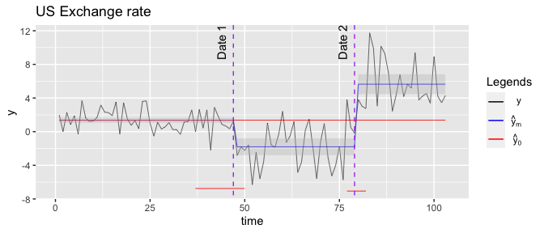

```r
#estimating the mean-shift model with BIC (the default option bic_opt=1, which use BIC as criterion)
rate_BIC = doorder('y',data=real)
#NOTE: equivalent to rate$BIC; type rate$BIC to compare with new result


# visualization of estimated model with BIC (in the argument, we can replace rate$BIC with rate_BIC for exact same graph; recall that `$` is the operator to refer to field BIC in return list from mdl())
plot_model(rate$BIC, title = 'US Exchange rate')
```

The `plot_model()` function takes any estimated structural break model of class `model` and makes a graph with the following contents:

- The observed $y$, fitted $\hat{y}_{m^*}$ values from a model with $m^*$ breaks (estimated or pre-specified depending on function called) and fitted $\hat{y}_0$ from a no break model for a direct comparison
- The estimated break dates with labels in chronological order and confidence interval depends on `CI` argument (which is either 0.90 or 0.95) for respective dates.
- The confidence interval (also depends on argument `CI`) for fitted values $\hat{y}_{m^*}$[^6]

To show flexibility of class `model` in the package, we can reproduce a similar graph using information returned from stored variable `rate_BIC`.

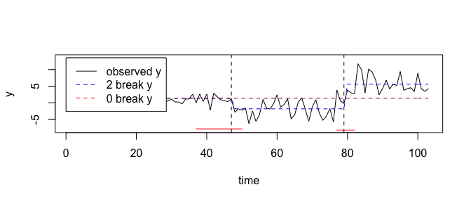

```r
  #collect model information
  m = rate_BIC$nbreak           #number of breaks
  y = rate_BIC$y                #vector of dependent var
  zreg = rate_BIC$z             #matrix of regressors with changing coefs
  date = rate_BIC$date          #estimated date
  fity = rate_BIC$fitted.values #fitted values of model
  bigT = length(y)
  #compute the null model
  fixb = solve((t(zreg) %*% zreg)) %*% t(zreg) %*% y
  fity_fix = zreg%*%fixb    #fitted values of null model


  #plots the model
  tx = seq(1,bigT,1)
  range_y = max(y)-min(y);
  plot(tx,y,type='l',col="black", xlab='time',ylab="y",
       ylim=c(min(y)-range_y/10,max(y)+range_y/10),lty=1)
  #plot fitted values series for break model
  lines(tx, fity,type='l', col="blue",lty=2)
  #plot fitted values series for null model
  lines(tx, fity_fix,type='l', col="dark red",lty=2)

  #plot estimated dates + CIs
  for (i in 1:m){
    abline(v=date[i,1],lty=2)
    if (rate_BIC$CI[i,1] < 0){rate_BIC$CI[i,1] = 0}
    if(rate_BIC$CI[i,2]>bigT){ rate_BIC$CI[i,2]=bigT}
    segments(rate_BIC$CI[i,1],min(y)*(12+i/m)/10,rate_BIC$CI[i,2],min(y)*(12+i/m)/10,lty=1,col='red')
  }

  legend(0,max(y)+range_y/10,legend=c("observed y",paste(m,'break y'),"0 break y"),
        lty=c(1,2,2), col=c("black","blue","red"), ncol=1)
```

### New Keynesian Phillips Curve

Perron and Yamamoto (2015) investigates the stability of New Keynesian Phillips curve model proposed by Galı and Gertler (1999) via linear model:

$$\pi_t = \mu + \gamma \pi_{t-1} + \kappa x_t + \beta E_t \pi_{t+1} + u_t$$

where $\pi_t$ is inflation rate at time t, $E_t$ is an expectation operator conditional on information available up to $t$, and $x_t$ is a real determinant of inflation. In this example, we will reproduce specific results of the paper with ready-to-use dataset:

```r
data(nkpc)
#x_t is GDP gap
  z_name = c('inflag','ygap','inffut')
  #we can invoke each test separately by using dotest() and doseqtests()
  supF_ygap = dotest('inf',z_name,data=nkpc,prewhit = 0, eps1 = 0.1,m=1)
  #z regressors' names are passed in the argument as an array, which equivalent to above argument call with z_name
  seqF_ygap = doseqtests('inf',c('inflag','ygap','inffut'),data=nkpc,prewhit = 0, eps1=0.1)
  #see test results
  supF_ygap

a) SupF tests against a fixed number of breaks

        1 break
Sup F    22.220
10% CV   14.810
5% CV    16.760
2.5% CV  18.620
1% CV    20.750

b) UDmax tests against an unknown number of breaks

   UDMax 10% CV  5% CV 2.5% CV  1% CV
1 22.220 15.230 17.000  18.750 20.750
  seqF_ygap

supF(l+1|l) tests using global optimizers under the null

               supF(2|1) supF(3|2) supF(4|3) supF(5|4)
Seq supF          12.559    22.294    13.565    18.463
Estimated date        92       125        17       125
10% CV            14.810    16.700    17.840    18.510
5% CV             16.760    18.560    19.530    20.240
2.5% CV           18.620    20.300    21.180    21.860
1% CV             20.750    22.400    23.550    24.130


#x_t is labor income share
  #or invoke all tests using mdl()
  nkpc_lbs = mdl('inf',c('inflag','lbs','inffut'),data=nkpc,prewhit = 0, eps1=0.1, m=5)

There are no breaks selected by BICand estimation is skipped

There are no breaks selected by LWZand estimation is skipped
  nkpc_lbs$sbtests

a) SupF tests against a fixed number of breaks

        1 break 2 breaks 3 breaks 4 breaks 5 breaks
Sup F    30.592   69.630   37.894   32.765   30.607
10% CV   14.810   13.560   12.360   11.430   10.610
5% CV    16.760   14.720   13.300   12.250   11.290
2.5% CV  18.620   15.880   14.220   12.960   11.940
1% CV    20.750   17.240   15.300   13.930   12.780

b) UDmax tests against an unknown number of breaks

   UDMax 10% CV  5% CV 2.5% CV  1% CV
1 69.630 15.230 17.000  18.750 20.750
  nkpc_lbs$seqtests

supF(l+1|l) tests using global optimizers under the null

               supF(2|1) supF(3|2) supF(4|3) supF(5|4)
Seq supF          11.408    11.595    12.564    26.418
Estimated date        88        17        88       125
10% CV            14.810    16.700    17.840    18.510
5% CV             16.760    18.560    19.530    20.240
2.5% CV           18.620    20.300    21.180    21.860
1% CV             20.750    22.400    23.550    24.130
```

To replicate the results, we turn off `prewhit` option. Compared the results obtained above with text box bordered in red in figure 3 below:

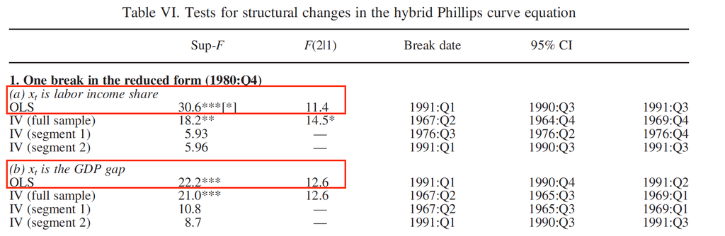

The values of SupF 30.6 and F(2|1) 11.4 test statistics are equivalent to 30.6 and 11.4 (upper red box) and the values 22.2 and 12.6 are equivalent to 22.2 and 12.6 (lower red box). Given the Sup F(2|1) statistics in both regressions is smaller than the 10% critical values 14.81 and both Sup F test statistic of 0 versus 1 break is larger than the 1% critical values 20.75, we conclude there is only 1 break detected.

The estimated break dates 1:Q1991 also match 1991:Q1 in the reported table. The package exactly replicates results presented in Perron and Yamamoto (2015). Given the estimated date from the sequential approach, we could split the sample into two subsamples and conduct the two stage least squares (2SLS) in each subsample as suggested by Perron and Yamamoto (2015):

|  | $\mu$ | $\gamma(\pi_{t-1})$ | $\kappa(x_t)$ | $\beta(E_t\pi_{t+1})$ |
| --- | --- | --- | --- | --- |
| 1960:Q1-1991:Q1 | 0.000 | 0.302 | 0.001 | 0.683 |
| $SE_1$ | 0.001 | 0.070 | 0.007 | 0.067 |
| 1991:Q2-1997:Q4 | 0.001 | 0.130 | 0.042 | -0.328 |
| $SE_2$ | 0.005 | 0.157 | 0.036 | 0.385 |

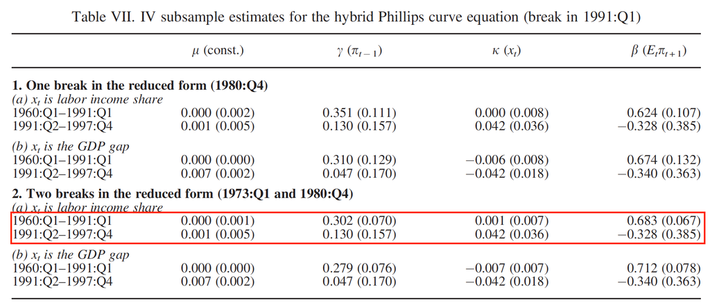

An extension we could consider is to look at the New Keynesian Phillips curve and attempt to figure which component in the specification ($\pi_{t-1},E_t\pi_{t+1},x_t$) has effects changed over time while holding other variables time-invariant.

```r
#create a separate data set to add constant regressor
nkpc_c = nkpc
#create constant regressor
nkpc_c$const = rep(1,151)
# if included a constant explicitly, users need to turn off option const, otherwise matrix of regressors is linearly dependent (2 const regressors) so non-invertible
# use sequential approach to estimate number of breaks for
# i) only expected inflation change
nkpc_inffut = dosequa('inf','inffut',c('const','inflag','ygap'),data=nkpc_c,signif = 1,const=0)

There are no breaks selected by sequential procedure and estimation is skipped

# ii) only expected inflation change
nkpc_ygap = dosequa('inf','ygap',c('const','inflag','inffut'),data=nkpc_c,signif = 1,const=0)

There are no breaks selected by sequential procedure and estimation is skipped

# iii) only expected inflation change
nkpc_inflag = dosequa('inf','inflag',c('const','inffut','ygap'),data=nkpc_c,signif = 1,const=0)

nkpc_inflag

The number of breaks is estimated by sequential procedure
Partial change model with 2 estimated breaks.
Minimum SSR = 0.001

Estimated date:
         Break1    Break2
Date         88       125
95% CI (82,169) (120,139)
90% CI (86,147) (122,135)

Estimated regime-specific coefficients:
                 Regime 1      Regime 2       Regime 3
inflag (SE) 0.001 (0.000) 0.453 (0.039) -0.001 (0.005)

Estimated full-sample coefficients:

               const (SE)   inffut (SE)     ygap (SE)
All regimes 0.487 (0.005) 0.430 (0.038) 0.333 (0.040)
```

If we hold other components of the New Keysian Phillips curve constant over the sample, only two changes in effects of lagged inflation $\pi_{t-1}$ are found at 10% significance level out of three models we are experimenting. We can visualize the change model versus the null model again:

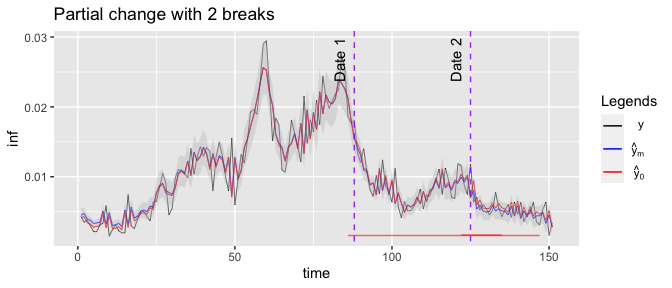

# Reference

Bai, J., 1997. Estimating multiple breaks one at a time. Econometric Theory 13, 315–352.

Bai, J., Perron, P., 2003. Computation and analysis of multiple structural change models. Journal of Applied Econometrics 18, 1–22.

Bai, J., Perron, P., 1998. Estimating and testing linear models with multiple structural changes. Econometrica 47–78.

Galı, J., Gertler, M., 1999. Inflation dynamics: A structural econometric analysis. Journal of Monetary Economics 44, 195–222.

Garcia, R., Perron, P., 1996. An analysis of the real interest rate under regime shifts. Review of Economics and Statistics 111–125.

Liu, J., Wu, S., Zidek, J.V., 1997. On segmented multivariate regression. Statistica Sinica 497–525.

Perron, P., Yamamoto, Y., 2015. Using ols to estimate and test for structural changes in models with endogenous regressors. Journal of Applied Econometrics 30, 119–144.

Yao, Y.-C., 1988. Estimating the number of change-points via schwarz’criterion. Statistics & Probability Letters 6, 181–189.

[^1]: Users can call independent functions to carry out specific procedures as outlined above instead of conducting all 6 main procedures provided by package via `mdl()`
[^2]: The high level functions are `mdl()`, `dofix()`, `dosequa()`, `dorepart()`, `doorder()`, `dotest()`, `doseqtests()`
[^3]: This argument is different from `eps` where `eps` sets the convergence criterion for iterative scheme when estimating partial change model.
[^4]: The results of pure structural change models are not affected by these options
[^5]: The above options are used extensively in all high-level functions of the program to specify required assumptions on structural break model. Additional options relating to formatting output in `plot_model()` function will not be explained in this section. For more information type `?plot_model()` or `?mdl()` to understand the distinctions between two types of options
[^6]: The option `CI` for `plot_model()` is used to specify the confidence interval around estimates of break dates and fitted values. For fitted values, it is computed as:
    $$(\hat{y}_t^{m^*-},\hat{y}_t^{m^*+}) = (x_t'(\hat{\beta}-Z_{CI} \hat{s.e.}(\hat{\beta}))+z_t'(\hat{\delta}-Z_{CI}\hat{s.e.}(\hat{\delta})),x_t'(\hat{\beta}+Z_{CI} \hat{s.e.}(\hat{\beta}))+z_t'(\hat{\delta}+Z_{CI}\hat{s.e.}(\hat{\delta})))$$
    where
    $$Z_{CI} = \begin{cases}
    1.96 & CI=0.95 \\
    1.65 & CI=0.90
    \end{cases}$$
    For break dates, the confidence interval is obtained via limiting distribution of $\hat{T}_j$ (Bai and Perron (1998))